# Experimental Sociology - Week 03

Analytical Methods: Ecological Models & Evolutionary Game Theory

Published

2025-03-21

# 🐒 Evolutionary Game Theory

In this chapter, we’ll gradually transition from **classical game theory**, with its perfectly rational and forward-looking actors, to **evolutionary game theory**, where strategies evolve over time.

While **evolution** is most famously associated with biology, it’s also a powerful and increasingly relevant concept in the **social sciences**. Here, we’re typically more interested in **cultural evolution** than biological evolution. The key difference lies in what changes: not the actors themselves, but the **strategies** they use.

In evolutionary game theory, strategies adapt based on their performance—successful ones tend to persist or spread, while ineffective ones are replaced, modified, or forgotten. This process allows us to model how behavior evolves in a population **without assuming perfect rationality**.

To describe an evolutionary process, we generally need three key ingredients:

- **Repeated interaction over time**  
  A setting where individuals (or populations) engage in many rounds of similar interactions.
- **Learning or imitation**  
  Rather than genes, ideas or strategies spread based on their success—this is sometimes referred to as **meme propagation** (in contrast to gene propagation).
- **Innovation or mutation**  
  New strategies can occasionally arise through experimentation, error, or random variation—mirroring biological mutation.

Together, these ingredients allow us to simulate and understand how cooperation, competition, and strategic behavior evolve—not in a static world of perfect calculation, but in the messy, adaptive reality of social life.

## 🎯 Learning Goals

By the end of this chapter, you should be able to:

- Explain the core ideas behind evolutionary game theory and how it differs from classical game theory.
- Identify the components of an evolutionary process: repetition, imitation, and mutation.
- Understand how strategies evolve in repeated games through population dynamics.
- Explore how cooperation can emerge and persist without centralized enforcement or perfect rationality.
- Analyze real-world situations—like social norms, trust, or punishment—using the tools of evolutionary game theory.

# 🦹 The Prisoner’s Dilemma

Most students of the social sciences are familiar with the **Prisoner’s Dilemma**, as illustrated in Table 1.

Table 1: A two-player Prisoner’s Dilemma. Each player’s best response is underlined. If they coincide, this constitutes a Nash equilibrium.

|  | Player 2: Cooperate | Player 2: Defect |
| --- | --- | --- |
| **Player 1: Cooperate** | $2, 2$ | $-1, \underline{3}$ |
| **Player 1: Defect** | $\underline{3},-1$ | $\underline{0}, \underline{0}$ |

**Note**

If an outcome is Pareto-inferior this means there exist another strategy profile that is at least for one player better and for nobody worse. Many rules in our societies try to overcome Pareto-inferior outcomes. Conversely, an outcome is Pareto optimal if there is no other outcome in the game that makes at least one individual better off without making someone else worse off.

Yet, when we look at real-world behavior, many social situations that resemble the Prisoner’s Dilemma often result in cooperation. For example, consider buying a product from an unknown seller in an online marketplace. Just materialistically, a buyer may be better off not paying (regardless of whether the item is shipped), and the seller may be better off not shipping (regardless of whether they are paid). Still, we frequently observe cooperation in such scenarios.

Does this mean game theory is wrong? Not necessarily. The issue is that the simple game above might not fully capture the true nature of the social interaction.

Take the online shop example: there’s often a **third party**—such as the state, police, or legal system—that can impose penalties on those who defect. With this additional outside force, the strategic situation resembles a modified game, shown in Table 2.

Table 2: A two-player Prisoner’s Dilemma with Punishment.

|  | Player 2: Cooperate | Player 2: Defect |
| --- | --- | --- |
| **Player 1: Cooperate** | $2, 2$ | $-1, 3-P$ |
| **Player 1: Defect** | $3-P,-1$ | $0-P, 0-P$ |

You can easily verify that this version has a unique Nash equilibrium at $(a_{1C}, a_{2C})$, provided the fine $P$ is greater than $1$. Hence, the punishment steers society into a **Pareto-optimal outcome**. Similarly, many social institutions and enforcement mechanisms exist to promote cooperation—at least to some extent—even in interactions that would otherwise resemble a classic Prisoner’s Dilemma.

While institutional mechanisms are an interesting topic, today we’ll focus on a much more subtle mechanism by which cooperation can emerge without third parties: through repetition.

Before you proceed. Just play around with https://ncase.me/trust/.

# 🔁 Repeated Games

A **repeated game**, sometimes also called **iterated game**, is a game that’s **played** not just once, but **several times in succession**. Each repetition is called a round, starting at round 1 and continuing for a fixed **number of rounds** $d$**,** a random number of rounds, or even indefinitely.

In repeated games, a strategy isn’t just a one-off decision—it’s a complete plan that specifies what a player will do in every round, potentially based on the outcomes of previous rounds. This adds a layer of complexity far beyond one-shot games.

To illustrate this, consider Table 3, which shows a twice-repeated Prisoner’s Dilemma. The original game is played twice by two players, each of whom chooses a sequence of actions like $(C, C)$, meaning they cooperate in both rounds.

Table 3: A twice repeated PD with two players and only some possible strategies.

|  | $(C,C)$ | $(D,C)$ | $(C,D)$ | $(D,D)$ |
| --- | --- | --- | --- | --- |
| $(C,C)$ | $4, 4$ | $1, 5$ | $1, 5$ | $-2, \underline{6}$ |
| $(D,C)$ | $5, 1$ | $2, 2$ | $2, 2$ | $-1, \underline{3}$ |
| $(C,D)$ | $5, 1$ | $2, 2$ | $2, 2$ | $-1, \underline{3}$ |
| $(D,D)$ | $\underline{6},-2$ | $\underline{3},-1$ | $\underline{3},-1$ | $\underline{0}, \underline{0}$ |

But this only scratches the surface. These strategies **do not yet take into account** how players might respond based on what happened in earlier rounds. A player might adopt a **contingent strategy**, such as:

- **Tit-For-Tat** (FTF): *“Cooperate in round 1, after that mimic the action of the other the round before”*

This opens the door to retaliation, forgiveness, trust-building, and many other dynamics that make repeated games a powerful framework for understanding real-world cooperation. Let’s take a closer look.

**Note**

In the context of repeated games, pure strategies represent a complete game plan—specifying exactly what a player will do in every round of the game. These strategies can be contingent, meaning they may depend on the entire history of previous rounds. As a result, strategies in repeated games are often far more complex than those in one-shot games.

A mixed strategy, in this setting, refers to a probabilistic combination of such complex pure strategies—not just mixing actions in a single round, but mixing over entire contingent plans.

In Table 3, the only Nash equilibrium is mutual and complete defection: both players choose $(D, D)$, defecting in both rounds. However, the landscape changes dramatically when we introduce this Tit-for-Tat.

Now consider Table 4, where we simplify the strategy space to just two strategies: TFT and complete defection (we will call it now **always defection aD**). This simplified game reveals something interesting: there are two Nash equilibria. If TFT meets TFT, both players will cooperate in the first round and continue cooperating in the second. If FTF meets $(D,D)$ on the other hand, TFT is in the first round exploited but then defects in the second round (it “retaliates”).

Table 4: A twice repeated PD with two players and two strategies.

|  | TFT | aD |
| --- | --- | --- |
| TFT | $\underline{4}, \underline{4}$ | $-1, 3$ |
| aD | $3,-1$ | $\underline{0}, \underline{0}$ |

Note: It’s not the strategy alone that makes this new Nash equilibrium possible—it’s the repetition of the game that enables it. In a one-shot game, Tit-for-Tat (TFT) simply plays $C$ (cooperate), since there’s no prior move to respond to. As such, it does not constitute a Nash equilibrium, as unilateral defection would yield a strictly higher payoff.

Alas, this kind of cooperation is **fragile**. Even though strategies like **Tit-for-Tat (TFT)** can support mutual cooperation, they are vulnerable to certain types of exploitation.

If a player knows that their opponent is using TFT, a clever counter-strategy is to **play TFT until the final round, then defect**, which we will call **TFT-1**. In our two-round game, this strategy is correspond to $(C, D)$, cooperate in round 1, then take advantage in round 2, knowing TFT won’t retaliate until it’s too late.

In Table 5, we add this TFT-1 strategy to the game alongside TFT and aD. The result is sobering: the introduction of this seemingly smart strategy leads to a chain of unilateral deviations, ultimately **eroding cooperation** and resulting in mutual defection as the only Nash equilibrium.

Table 5: A twice repeated PD with two players and three strategies.

|  | TFT | TFT-1 | aD |
| --- | --- | --- | --- |
| TFT | $4, 4$ | $1, \underline{5}$ | $-1, 3$ |
| TFT-1 | $\underline{5}, 1$ | $2, 2$ | $-1, \underline{3}$ |
| aD | $3,-1$ | $\underline{3},-1$ | $\underline{0}, \underline{0}$ |

**Note**

Adding more strategies isn’t always better—neither for society nor for the players themselves. The simplest way to ensure cooperation in the Prisoner’s Dilemma? Remove the option to defect altogether.

To **preserve cooperation**, we must move beyond the limitations of **finitely repeated games** and look at **infinitely repeated games**. In this setting, the shadow of the future looms large—**players always expect another round**, which makes retaliation credible and cooperation sustainable.

### Infinitely Repeated Games

When we talk about **infinitely repeated games**, we usually mean *theoretically* infinite games—because in practice, there’s no such thing.

There are two good reasons for this:

1. **All real-world games must end.** No interaction can go on forever—eventually, life intervenes (people move away, change jobs, or, well… die).
2. **True infinity breaks our models.** No matter how small or large the payoffs are, multiplying them by infinity leads to undefined or unbounded utilities. That makes it impossible to meaningfully compare or predict outcomes.

To deal with this, game theorists often (always?) model infinite repetition *probabilistically*. Specifically, we assume the game continues into the next round with a certain probability $\delta > 0$. This is called a **discount factor**.

In this version of the game:

- The interaction might end after the very first round,
- Or it might continue—perhaps for a very long time—depending on the realization of $\delta$ at each step.

From the players’ perspective, they don’t know when the game will end. This uncertainty is *key*. It captures two realistic features of many social interactions:

1. **We often expect to meet again**, but we can’t be sure.
2. **It distinguishes between** one-shot games (known single encounters) and situations with an **uncertain horizon**—what we refer to as infinitely repeated games.

This approach also solves our utility problem.

Imagine an infinitely repeated game where a player earns a utility of $1$ per round no matter what they do (yes, not very exciting, but bear with me). How much total utility do they get?

Well, it depends on how many rounds are actually played. If it ends after 1 round, it’s just $1$. If it lasts for 4 rounds, it’s $4$, and so on.

Fortunately, we can calculate the **expected number of rounds** based on $\delta$, the probability that the game continues after each round.

Let’s compute that:

If $\delta$ is the continuation probability, the expected number of rounds (called $d$) is given by:

$$d = \mathbb{E}[\text{Rounds}] = 1 + \delta + \delta^2 + \delta^3 + \dots = \sum_{t=0}^{\infty} \delta^t = \frac{1}{1 - \delta}$$

So, if $\delta = 0.9$, we expect the game to last:

$$d = \frac{1}{1 - 0.9} = 10 \text{ rounds}$$

We can also calculate the **expected utility** for a player $i \in N$ in such a game—assuming the player receives the same payoff $u(a_i)$ in each round (if payoffs vary over time, the calculation is more complex):

$${EU}_i(a_i) = u(a_i) + u(a_i) \cdot \delta + u(a_i) \cdot \delta^2 + u(a_i) \cdot \delta^3 + \dots = u(a_i) \cdot \sum_{t=0}^{\infty} \delta^t = \frac{u(a_i)}{1 - \delta}
\tag{1}$$

This concept of **discounted infinite repetition** allows us to model cooperation, trust, and long-term strategy in a mathematically sound way—without running into the problems of true infinity.

#### Alternative Interpretation of $\delta$

There’s another way to interpret the parameter $\delta$, suggested by its name: the **discount factor**.

Instead of seeing $\delta$ as the probability that another round will happen, we can view it as a measure of how much players **devalue future payoffs**. That is, players care **less** about what happens tomorrow than what happens today.

This makes intuitive sense. Imagine you’re offered two options:

- €1,000,000, twenty years from now.
- A smaller amount—say €500,000 or even €200,000, right now.

How much would you be willing to accept today to forgo the future amount of €1,000,000? Depending on your personal **threshold** (or *indifference point*), we could compute your **discount factor**—that is, how much you value future utility compared to present utility.

The cool thing is: **both interpretations lead to the same formula** for expected utility!

So even if we assume the game is truly infinite (and apply discounting), we arrive again at:

$$\text{EU}_i(a_i) = \frac{u(a_i)}{1 - \delta}$$

Whether you interpret $\delta$ as a **probability of continuation** or a **discount factor**, the math remains the same. You’re free to choose whichever interpretation fits your modeling needs—or even **combine both**.

If we distinguish between: - $\delta_d$: the **discounting** of future utility, and - $\delta_p$: the **probability** of continuation,

then the combined expected utility becomes:

$$\text{EU}_i(a_i) = u(a_i) + u(a_i) \cdot \delta_d \delta_p + u(a_i) \cdot \delta_d^2 \delta_p^2 + \dots = u(a_i) \cdot \sum_{t=0}^{\infty} (\delta_d \delta_p)^t = \frac{u(a_i)}{1 - (\delta_d \delta_p)}$$

However, in practice it’s often simplest to define:

$$\delta = \delta_d \cdot \delta_p$$

That is, **think of them together**—since they typically operate hand-in-hand. This keeps the model simple, elegant, and flexible.

## Analyzing Repeated Games

In the following, we will refer to **repeated games** as shorthand for **infinitely repeated games with a discount factor**, unless stated otherwise. If we mean games repeated a fixed number of times, we will explicitly call them **finitely repeated games**.

Let’s return to the example in Table 5, where cooperation broke down due to the presence of TFT-1. This strategy works in finitely repeated games because players know exactly when the final round is—and can thus time their *betrayal*.

However, in infinitely repeated games with a discount factor, this kind of timing isn’t possible. **No one knows when the last round will occur**. As a result:

- Some strategies feasible in finitely repeated games—like TFT-1—**can’t be implemented**.
- At the same time, infinitely repeated games offer a **vastly richer space of strategies**—in fact, infinitely many.[^1]

Let’s say our discount factor is $\delta = 0.5$. That implies the expected number of rounds is $2$, so we could return to Table 4 as a representative of the expected interaction length. Now, in a finitely repeated game with two rounds, TFT was vulnerable to TFT-1 (or $(C, D)$). But in an infinitely repeated game, **TFT-1 no longer exists** as a viable strategy. There is no way to *save up* for a final betrayal, because no one knows when the final round is coming.

**Hooray! Cooperation is saved!**

Or is it?

Well two important questions might arise from this:

1. Is there another strategy (one that can exist in a repeated game) that can exploit TFT and destroy cooperation again?
2. If so, is there a strategy that can resist even those strategies and ensure cooperation in the long run (i.e. is there a most successful strategy)?

Well, the answers to these questions is rather complex as we will see.

One of the most influential efforts in studying strategy success in repeated games was carried out by **Robert Axelrod** in the 1980s Axelrod and Hamilton (1981). In his famous **computer tournaments**, researchers from various disciplines were invited to submit strategies to compete in repeated Prisoner’s Dilemma matchups against one another. The setup was simple: each strategy played a series of Prisoner’s Dilemmas against every other strategy over an **unknown number of rounds**.

So, did Axelrod discover the “best” strategy?

In the first tournament (Axelrod 1980a), the clear winner was **Tit-for-Tat (TFT)**—a simple yet elegant strategy that cooperated on the first move and then copied the opponent’s last move thereafter. However, Axelrod noted that a slightly modified version, called **2TFT (Two-Tit-for-Tat)**—which only retaliates after two consecutive defections—**would have performed even better**, had anyone submitted it.

Encouraged by the results, Axelrod organized a second tournament (Axelrod 1980b) with broader participation and even more competitive entries. This time, 2TFT was submitted—but it didn’t fare as well. Why? Because many strategies were purposefully designed to **exploit** the forgiveness of 2TFT. Once again, the original **TFT** strategy emerged as the most successful.

This leads to an important insight:

**Note**

There is no universally best strategy in a repeated game. The success of a strategy depends on its **environment**—that is, the other strategies it competes with.

While Axelrod only tested a relatively small set of strategies (63 in total), his experiments revealed important **correlates of strategic success**—that is, characteristics that tend to perform well over time in repeated interactions.

**Note**

Based on his findings, Axelrod identified three traits that successful strategies typically share:

- **Be nice** – Don’t be the first to defect.
- **Be provokable** – Retaliate quickly when wronged.
- **Be forgiving** – Once retaliation has occurred, return to cooperation when possible.

However, there’s a key limitation to Axelrod’s tournament setup: The strategy pool—**the population**—was static. There was **no learning**, **no innovation**, and **no evolution** over time. Strategies competed, but they didn’t adapt, mutate, or spread based on success.

And that’s exactly where we’re headed next.

# 🎓 Ecological Models with Learning

In Axelrod’s famous tournaments, each strategy was represented exactly once, and the population was **static**—no strategy changed, evolved, or disappeared over time. However, in real-world social and biological systems, this is rarely the case. In reality, strategies **compete**, **spread**, and **evolve**. Individuals **imitate** more successful behaviors, **learn** from experience, or **innovate** entirely new approaches. This leads to a dynamic population of strategies, constantly adapting over time, this is what **ecological models** are.

To capture this process, we must go beyond static game-theoretic analysis and adopt a new perspective:  
a **population-level view**, where strategies evolve within a system based on their **success**. The engine of this evolution is what we call the **fitness function**. In evolutionary game theory, fitness reflects how well a strategy performs in a given population context. The better its fitness, the more it spreads.

This spread can happen in many ways:

- In **biological evolution**, fitter strategies might correspond to organisms that reproduce more successfully.
- In **cultural evolution**, less successful individuals may **imitate** more successful ones.
- In **learning models**, individuals may adopt strategies based on **reinforcement**, **payoffs**, or **trial and error**.

No matter the interpretation, the effect is the same: **More successful strategies grow in frequency**. Less successful ones decline—and may eventually vanish. Over time, this process **reshapes** the **population**, often settling into a stable distribution of strategies—a so-called **evolutionary equilibrium**.

This abstraction is one of the strengths of evolutionary modeling: it allows us to model many real-world processes—biological, social, or economic—using a single unified framework.

**Note**

**Ecological models** are repeated games with learning.

## From Mixed Strategies to Mixed Populations

In **classical game theory**, players in a **game** can randomize over strategies using **mixed strategies**. For example, a player in the Matching Pennies (Table 6) game might choose heads and tails each with probability $0.5$. In **evolutionary game theory**, we shift perspective. Instead of two players each mixing over strategies, we imagine a **population of players** that constitute a **system**, each committed to exactly **one pure strategy**. There is no individual mixing. Instead, the **population itself is mixed**—some individuals always play heads, others always play tails.

Let’s revisit the Matching Pennies game shown in Table 6. In classical theory, the Nash equilibrium is for both players to play $(0.5,\ H;\ 0.5,\ T)$. From an evolutionary perspective, the system is in equilibrium if **half of the population adopts strategy** $H$ and **the other half adopts strategy** $T$. It doesn’t matter whether the population consists of 2 individuals, 1,000, or even a 1,000,000—all that matters is the **relative frequency** of each strategy in the population.

Table 6: Matching Pennies. The first number in each cell is Player 1’s utility; the second is Player 2’s.

|  | Player 2: H ($p_2$) | Player 2: T ($1-p_2$) |
| --- | --- | --- |
| **Player 1: H** ($p_1$) | $\underline{1}, -1$ | $-1, \underline{1}$ |
| **Player 1: T** ($1-p_1$) | $-1, \underline{1}$ | $\underline{1}, -1$ |

### Defining a Population

A population $Q$ is represented as an $k$-tuple of relative frequencies for $k$ different strategies:

$$Q = (q_1, q_2, \dots, q_k), \quad \text{with} \quad \sum_{i=1}^{k} q_i = 1 \quad \text{and} \quad q_i \geq 0 \ \forall i.$$

Each $q_i$ represents the share of the population using strategy $i$. The vector $Q$ defines the **state of the system** at any given point in time.

We can represent such populations graphically using a **simplex**, specifically an $S_n$ simplex, where $n$ is the number of distinct strategies in the population.

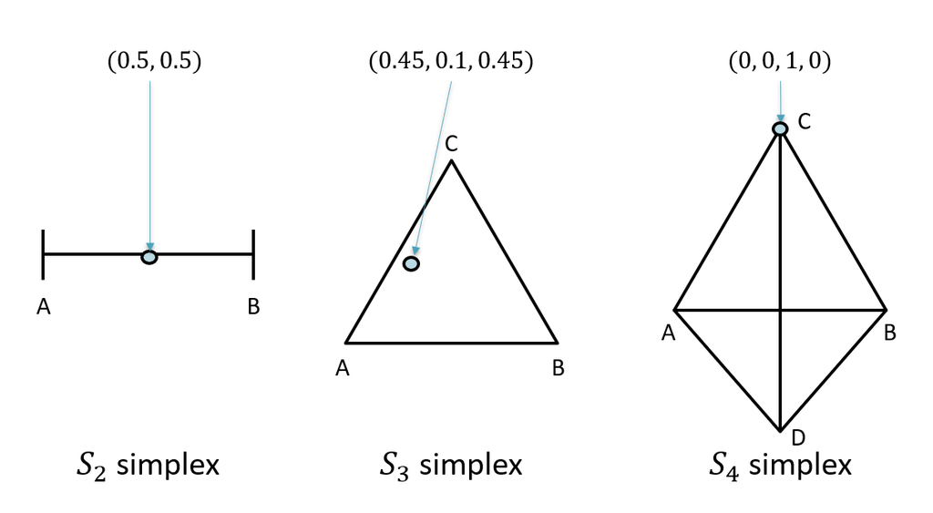

Figure 1: Three graphical representations via simplexes. Each point inside a simplex represents a certain population distribution.

In Figure 1, we see three examples:

- $S_2$ simplex: a line segment representing a population with **two** strategies.
- $S_3$ simplex: a triangle representing a population with **three** strategies.
- $S_4$ simplex: a 3D shape (projected here in 2D) representing **four** strategies.

Each point within a simplex corresponds to a specific **distribution of strategies** within the population.

Let’s look more closely at the $S_2$ simplex:

- A point on the **left end** means the population consists entirely of **Strategy A**.
- A point on the **right end** means the population consists entirely of **Strategy B**.
- A point exactly **in the middle** (as shown) means the population is **evenly split: 50% A and 50% B**.

This geometric view allows us to model and visualize **how populations evolve over time** under various evolutionary dynamics.

### From Utiltiy Function to Fitness Function

The core idea of evolutionary game theory is that the **relative success of a strategy** determines whether it spreads or vanishes from the population. If a strategy performs well—meaning it earns **higher payoffs**—then it will **grow in frequency** over time. Conversely, poorly performing strategies tend to **shrink** and may eventually **go extinct**.

This concept is captured by what we call the **fitness function**. In essence, a **fitness function** plays the same role in evolutionary models as a **utility function** does in classical game theory. Both represent how well a strategy performs. However, we use different terms to clarify the analytical framework.

The general form for a fitness matrix $F$ is:

$$F = [f_{ij}] = \begin{pmatrix}
f_{11} & \cdots & f_{1n} \\
\vdots & \ddots & \vdots \\
f_{n1} & \cdots & f_{nn}
\end{pmatrix}$$

Let’s try to **translate** the repeated game from Table 4 into a **fitness matrix**. This matrix represents the payoffs from interactions between individuals who adopt one of two pure strategies TFT (Tit-for-Tat) and aD (always Defect). Each entry shows the **expected fitness** (success) of a player using one strategy when matched against another. In Table 7, we interpret the **utility values** of Player 1 as their **fitness advantage** $f$ in a population context. The perspective now shifts: we’re no longer focusing on individual player matchups but on **entire populations** of individuals using different strategies.

Table 7: A fitness matrix with two strategies in a PD with TFT and aD, and $\delta=0.5$.

|  | TFT | aD |
| --- | --- | --- |
| TFT | $f_{TFT,TFT}=4$ | $f_{TFT,aD}=-1$ |
| aD | $f_{aD,TFT}=3$ | $f_{aD,aD}=0$ |

Each cell tells us the fitness of a strategy (row) when interacting with another strategy (column). This matrix will be the basis for defining the **evolutionary dynamics** of the population.

**Note**

Note that evolutionary models (at least for now) make sense only for **symmetric games** like the Prisoner’s Dilemma. In **asymmetric games**—such as the Inspection Game—we’d have to model separate populations (e.g., buyers and inspectors), or assume that actors can switch roles. In the latter case, we would also need to define outcomes when, say, an inspector meets another inspector.

**Note**

Summary of the changes from classical game theory to evolutionary game theory:

- Instead of games **systems** are analyzed.
- Instead of **utilities** each strategy has a **fitness** value to describe success.
- **Population shares** $q_i$ are the evolutionary analog to **mixed strategies** in classical game theory—they describe how prevalent a strategy is in the population, not how likely an individual is to play it.

## Analyzing the System

Now that we’ve defined population shares and fitness, we’re ready to model how strategies **evolve over time**.

Let’s begin by defining the **average fitness of a strategy** $f_i$. Fitness reflects how well a strategy performs **on average** when it is randomly matched with others in the population. It depends both on the distribution of strategies and the outcomes of interactions.[^2]

Given a population with $k$ strategies, where $q_j$ is the relative frequency of strategy $j$, and $f_{ij}$ is the fitness that strategy $i$ receives when interacting with strategy $j$, the **average fitness of strategy** $i$ is:

This equation tells us how successful strategy $i$ is in the current population, based on:

- How common each strategy $j$ is, and
- How well $i$ performs when matched against $j$

In short, **fitness is frequency-dependent**: a strategy’s success depends not just on its own design, but also on the **strategic environment** it is embedded in.

**Tip**

**Normalizing Fitness Matrices in Replicator Dynamics**

Replicator dynamics **do not change** if you **add or subtract a constant value from any column** of the fitness matrix.

This is useful because we can often **normalize** the matrix to simplify calculations—especially to set all diagonal elements to zero.

Let’s take the following matrix $F$:

$$F = \begin{pmatrix}
4 & 2 & 1 \\
3 & 1 & 3 \\
5 & 0 & 2
\end{pmatrix}$$

We now **subtract the diagonal entries from each column**:

- Subtract $4$ from column 1,
- Subtract $1$ from column 2,
- Subtract $2$ from column 3.

Resulting in:

$$F' = \begin{pmatrix}
0 & \phantom{-}1 & -1 \\
-1 & \phantom{-}0 & \phantom{-}1 \\
\phantom{-}1 & -1 & \phantom{-}0
\end{pmatrix}$$

Both matrices $F$ and $F'$ lead to the **same replicator dynamics**, because the differences between strategies—what really drives selection—stay the same. Yet, $F'$ is easier for us to use in calculations.

### Replicator Dynamics

So how do we model how these strategies evolve?

In evolutionary game theory, one of the most widely used tools for this is the **replicator dynamics**. This approach describes how the proportion of a strategy in the population changes as a function of its performance **relative to the population average**.

Let $q_i(t)$ denote the share of strategy $i$ at time $t$, and $f_i(Q)$ its fitness in the current population state $Q$. Then the **replicator equation** is defined as:

$$q_i^`(t)= \frac{dq_i}{dt} = q_i \left(f_i(Q) - \phi \right)
\tag{2}$$

Where:

- $f_i(Q)$ is the fitness of strategy $i$
- $\phi$ is the **average fitness of the population**, calculated as:

$$\phi = \sum_{i=1}^k q_i f_i(Q)$$

with $k$ being the number of strategies in this system.

The intuition behind the replicator equation is simple yet powerful:

- If a strategy’s fitness $f_i(Q)$ is **greater than the average fitness** $\phi$, then $q_i$ **increases** over time.
- If a strategy’s fitness is **lower than average**, then $q_i$ **decreases**.
- If $f_i(Q) = \phi$, the strategy’s share remains constant—it is **neutral** in the population.

This differential equation captures the **selection process**: successful strategies grow; unsuccessful ones decline.

In the case of our $S_2$ simplex with strategies TFT and aD, we can now plug in the fitness expressions we derived earlier and study how the shares of these strategies change over time.

In the next section, we’ll do exactly that—and explore how to **visualize** and **simulate** this dynamic behavior in the simplex.

### Example: Replicator Dynamics for TFT vs. aD

Let’s start by substituting in the values from the fitness matrix at Table 7 into our average fitness function for each strategy:

$$f_{\text{TFT}}(Q) = 4 \cdot q_{\text{TFT}} - 1 \cdot q_{\text{aD}} = 4q_{\text{TFT}} - q_{\text{aD}}$$

$$f_{\text{aD}}(Q) = 3 \cdot q_{\text{TFT}} + 0 \cdot q_{\text{aD}} = 3q_{\text{TFT}}$$

In order to simplify the notation let’s define:

- $q = q_{\text{TFT}}$
- $1 - q = q_{\text{aD}}$

Then the **average fitness** $\phi$ is:

$$\begin{align*}
\phi & = q \cdot f_{\text{TFT}}(Q) + (1 - q) \cdot f_{\text{aD}}(Q) \\
& = q (4q - (1-q)) + (1 - q)(3q) \\
& = 5q^2 - q + 3q - 3q^2 \\
& = 2q^2+2q
\end{align*}$$

Now, plug it into the **replicator equation** Equation 2:

$$\begin{align*}
\frac{dq}{dt} & = q \left( f_{\text{TFT}}(Q) - \phi \right) \\
& = q \left( (4q - (1-q)) - (2q^2 + 2q) \right) \\
& = q(5q - 1 - 2q^2 - 2q) \\
& = 3q^2 - 1q - 2q^3 \\
\end{align*}$$

What does this equation tell us?

The easiest way to interpret it is visually: take a look at Figure 2, which plots $\frac{dq}{dt}$—the rate of change in the share of TFT—against $q$, the current share of TFT in the population.

**Show R Code (Replicator Dynamic)**

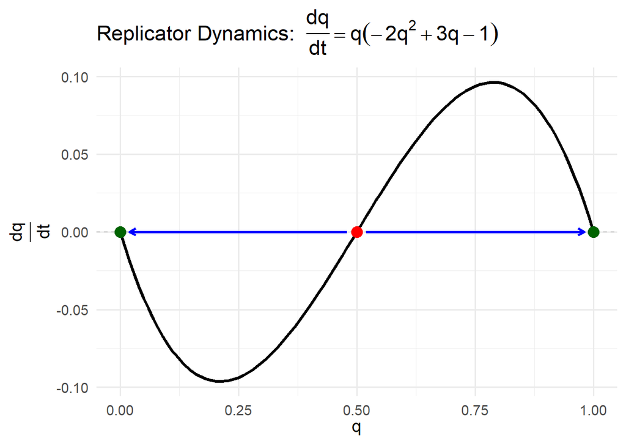

Figure 2: Replicator dynamics for two strategies (TFT and aD) and $\delta = 0.5$. The equation shows how the share of strategy TFT ($q$) changes depending on the current share of $q$. The green dots are stable equilibria, the red dot is an unstable equilibrium.

```r
library(ggplot2)
library(grid)  # for arrow()

# Define the replicator function
replicator <- function(q) {
  3 * q^2 - 1 * q - 2 * q^3
}

# Create a sequence of q values between 0 and 1
q_vals <- seq(0, 1, length.out = 101)

# Compute the rate of change dq/dt
dq_dt <- replicator(q_vals)

# Create a data frame for plotting
df <- data.frame(q = q_vals, dq_dt = dq_dt)

# Plot
ggplot(df, aes(x = q, y = dq_dt)) +
  geom_line(color = "black", size = 1.2) +
  geom_hline(yintercept = 0, linetype = "dashed", color = "gray") +
  # Add equilibrium points
  geom_point(data = subset(df, abs(dq_dt) == 0 &  (q == 0 | q == 1)), aes(x = q, y = dq_dt), color = "darkgreen", size = 4) +
  geom_point(data = subset(df, abs(dq_dt) == 0 & !(q == 0 | q == 1)), aes(x = q, y = dq_dt), color = "red", size = 4) +
  # Add arrows from q = 0.5 toward 0 and toward 1
  annotate("segment", x = 0.48, y = 0, xend = 0.02, yend = 0,
               arrow = arrow(length = unit(0.2, "cm")), color = "blue", linewidth = 1) +
  annotate("segment", x = 0.52, y = 0, xend = 0.98, yend = 0,
               arrow = arrow(length = unit(0.2, "cm")), color = "blue", linewidth = 1) +
  labs(
    title = expression("Replicator Dynamics: " ~ frac(dq, dt) == q*(-2*q^2 + 3*q - 1)),
    x = expression(q),
    y = expression(frac(dq, dt))
  ) +
  theme_minimal(base_size = 14)
```

This graph reveals **three equilibria**, where $\frac{dq}{dt} = 0$: - $q = 0$ - $q = 0.5$ - $q = 1$

These are indicated as **dots in the plot**:

- The equilibria at $q = 0$ and $q = 1$ are marked green– these are **stable**.
- The equilibrium at $q = 0.5$ is marked red – this one is **unstable**.

Let’s walk through what happens in each interval:

- If $0 < q < 0.5$, then $\frac{dq}{dt} < 0$ → TFT **declines** → the population moves toward $q = 0$
- If $0.5 < q < 1$, then $\frac{dq}{dt} > 0$ → TFT **increases** → the population moves toward $q = 1$

The graph’s **blue arrows** illustrate this movement toward the stable endpoints. The unstable equilibrium at $q = 0.5$ acts like a tipping point: even a **small deviation** will send the system drifting toward one of the extremes, where only one strategy remains.

We now have a **clear, dynamic prediction** based on the **initial condition** $q_0$ (i.e., the starting share of TFT). In contrast, **classical game theory** might identify multiple **Nash equilibria** for such a game but offers **no guidance** on which one will actually be observed. **Evolutionary dynamics** fill this gap by allowing us to study **stability** and **basins of attraction**, which makes the theory **predictive** rather than merely descriptive.

We can summarize the evolutionary outcomes of this system in three clear hypotheses:

- **H1**: If $q_0 < 0.5$, then the population will evolve toward full defection. (formally: $\lim_{t \to \infty} q(t) = 0$)
- **H2**: If $q_0 > 0.5$, then the population will evolve toward full cooperation. (formally: $\lim_{t \to \infty} q(t) = 1$)
- **H3**: If $q_0 = 0.5$, the system will stay balanced, but any small fluctuation will push it toward one of the extremes.

### Evolutionarily Equilibria

Let $Q^*$ be a candidate equilibrium—i.e., a point where $\forall i \in \{1,2,\ldots,k\}: \frac{dq_i}{dt} = 0$.

- $Q^*$ is **unstable** if a small deviation causes the system to move away from $Q^*$:
- $Q^*$ is **stable** if a small deviation causes the system to return to $Q^*$:

This is visualized in Figure 3:

- A **stable equilibrium** occurs when the replicator dynamic curve **crosses the** $x$-axis from above (s shape).
- An **unstable equilibrium** occurs when the curve **crosses the** $x$-axis from below (z shape).

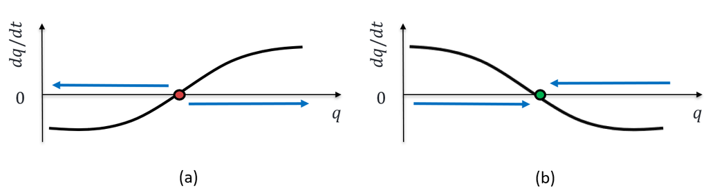

Figure 3: (a) An unstable equilibrium: the replicator dynamics point away from this value.  
(b) A stable equilibrium: the dynamics point back toward the equilibrium from both sides.

These dynamics help us understand which equilibria are likely to **persist** under real-world evolutionary processes—and which are too **fragile** to be observed in real live.

For completeness there is also a third type of evolutionary equilibrium (it is more relevant if we have at least 3 strategies):

- **Lyapunov-stable equilibrium**: A small deviation does **not** lead the system back to $Q^*$, but it also doesn’t move it far away—it stays **close** to $Q^*$ for all future times. This can mean it is stationary or it moves closely to $Q^*$ for all time.

Let us visualize these three equilibria in a $S_3$:

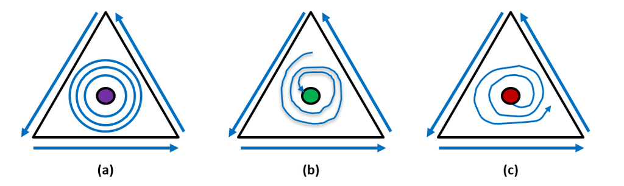

Figure 4: (a) Ljapunow-stable equilibrium, small changes from $Q^*$ “orbit” around the old equilibrium (b) Stable equilibrium, small chances lead back to $Q^*$ (c) Unstable equilibrium, small changes lead away from $Q^*$.

**Note**

In evolutionary game theory, an **equilibrium** refers to a population state in which the **relative shares of strategies no longer change**—in other words, $\forall i \in \{1,2,\ldots,k\}: \frac{dq_i}{dt} = 0$. This is similar to a **Nash equilibrium** in classical game theory, where no player has an incentive to unilaterally change their strategy. But evolutionary models go further by distinguishing between **stable** and **unstable** equilibria:

- **Stable equilibrium** (🟢 green dot): If the population is slightly perturbed, it **returns** to this point.
- **Unstable equilibrium** (🔴 red dot): A small perturbation causes the system to **move away** from this point.
- **Lyapunov-stable** **equilibrium** (🟣 lila dot): A small perturbation causes the system to **stay near** this point.

This distinction is crucial—while unstable equilibria are mathematically valid, they’re **rarely observed** in the real world because they can’t withstand noise or fluctuation.

**Note:** While **every Nash equilibrium** corresponds to an **evolutionary equilibrium** (whether stable or unstable), the reverse is **not always true**. That is, some evolutionary equilibria do **not** correspond to Nash equilibria (see also pre-class assignment 3).

# 💡 Evolutionary Models with Innovation

Finally, we turn to **fully evolutionary models**—that is, models that are not only ecological but also include the possibility of **innovation** (or **mutation**). This means that at any point in time, there is a small but **positive probability** that a strategy $i$—even if it currently has a population share of $q_i = 0$—might appear in the system. Formally, we say that strategy $i$ can **invade** the system.

Unfortunately, many interesting games—such as the repeated Prisoner’s Dilemma—include an **infinite set of possible strategies**. This makes it analytically infeasible to model mutation exhaustively. We cannot integrate an infinite strategy space into a closed-form model. Still, we can make progress by **trying out specific strategies** to see how they perform. In the coming weeks, we’ll do this using **agent-based models** (see next chapters), which allow us to simulate strategy innovation and adaptation dynamically.

Even if we can’t model every mutation analytically, we can still study **which strategies are stable to invasion**. This is incredibly useful, especially when considering **unstable equilibria at the edges of a simplex**.

For example, in the repeated Prisoner’s Dilemma, the state where **everyone always cooperates** ($q_{\text{aC}} = 1$) is an **unstable equilibrium**. As soon as a small fraction of the population mutates from aC (always cooperate) to aD (always defect), the system starts to shift. Eventually, the defectors take over, and we end up with $q_{\text{aD}} = 1$.

In short: **evolution doesn’t just reward success—it punishes vulnerability**.

**Note**

**Evolutionary models** are ecological models with mutation.

### Evolutionarily Stable Strategies (ESS)

An equilibrium in the context of replicator dynamics is reached when the proportions $q_i$ no longer change over time—that is, $q_i^`(t) = 0$ for all strategies. A particularly important concept is that of an **Evolutionarily Stable Strategy (ESS)**. A strategy $i$ is an ESS if, when it is adopted by nearly all members of the population, no mutant strategy $j \neq i$ can invade. Formally, $i$ is evolutionarily stable if, for any alternative strategy $s$:

1. $f_{ii} > f_{ji}$, or
2. $f_{ii} = f_{ji}$ and $f_{ij} > f_{jj}$.

This condition ensures that once an ESS is established, it cannot be replaced by a small group of invaders employing a different strategy.

# 🏋 Pre-Class Assignment

Read the assigned materials, then try to solve the following problems:

1. [easy] Modify Table 5, use $d=3$ instead of $d=2$.
2. [easy] Normalize the fitness matrix given in Table 7.
3. [medium] Translate the game Table 6 into fitness function and show, that is has three evolutionary equilibria. What do you notice in comparison to the equilibrium predictions of classical game theory?
   1. What is the problem if we want to translate the game Table 6 into fitness function?
   2. Translate the game Table 8 into fitness function and show, that is has three evolutionary equilibria.

      Table 8: Hawk-Dove-Game

      |  | Player 2: Hawk | Player 2: Dove |
      | --- | --- | --- |
      | Player 1: Hawk | $1, 1$ | $4, 2$ |
      | Player 1: Dove | $2, 4$ | $3, 3$ |

4. [hard] If you looked at https://ncase.me/trust/ under 5. “The evolution of distrust” Case shows that the number of rounds (in their case fixed numbers of rounds, but we will think of them as expected number of rounds) are crucial whether given the initial distribution of TFT or aD prevails in the end. This is because the number of rounds $d$ directly affect the fitness of both strategies. Model and analyze the replicator dynamics for $q=Q_{TFT}$ for the general case of $d$ rounds.
5. [medium] Show that aD and TFT are ESS, show that aC is not (only use this three strategies).

# 🚀 Link to In-Class Material

Here is the link for the in-class material.

## References

Axelrod, Robert. 1980a. “Effective Choice in the Prisoner’s Dilemma.” *Journal of Conflict Resolution* 24 (1): 3–25. https://doi.org/10.1177/002200278002400301.

———. 1980b. “More Effective Choice in the Prisoner’s Dilemma.” *Journal of Conflict Resolution* 24 (3): 379–403. https://doi.org/10.1177/002200278002400301.

Axelrod, Robert, and William Donald Hamilton. 1981. “The Evolution of Cooperation.” *Science* 211 (4489): 1390–96.

## Footnotes

[^1]: A simple example is the family of strategies called **Sneaky-TFT-**$n$, where the player plays Tit-for-Tat but defects every $n$-th round. Since the game might continue forever, we could define Sneaky-TFT-1, Sneaky-TFT-2, Sneaky-TFT-3, and so on—an infinite family of strategic variations.
[^2]: This framework correspond to the ideas that all actors in the populations are connected to each other (complete network) and that each actors interacts with everybody else once per round.

## Copyright

Copyright Sascha Grehl, 2025. All Rights Reserved